# Select Seed Lots under Climate Change Scenarios

Reed Benkendorf, Rob Massatti & Daniel Shyrock

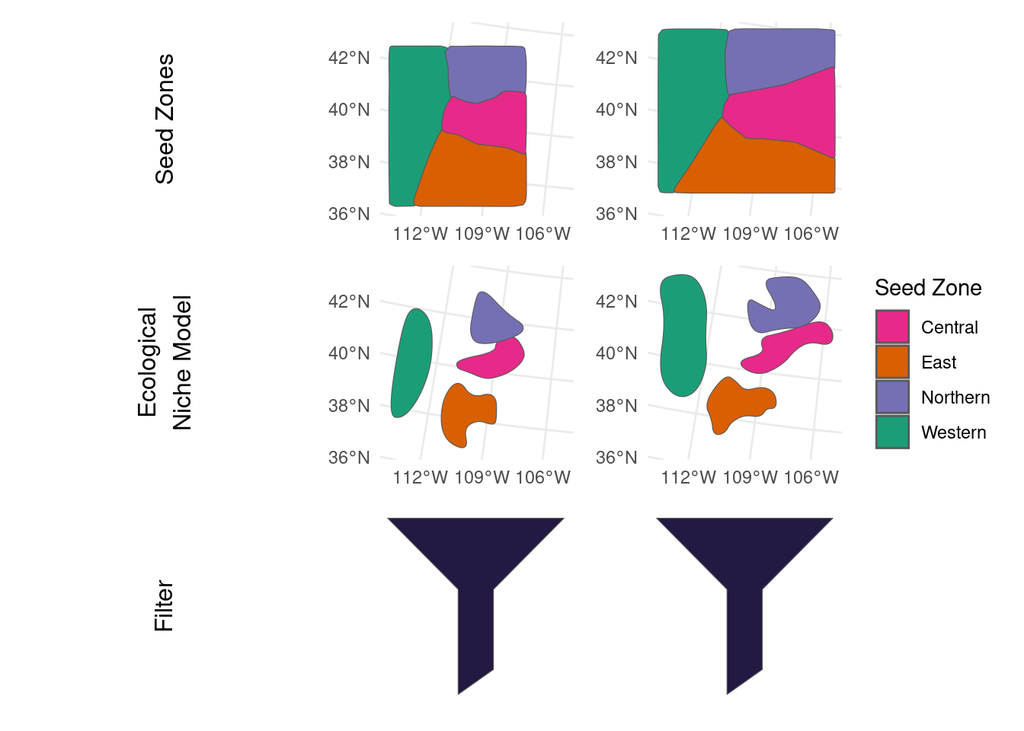

[figure not shown]

## Filter (‘Sieve’) Areas

Environmental filters can be effectively set by masking raster pixels into 0/1 conditions, whereby 0 or masked cells are removed from downstream analysis, and 1 pixels allow the inclusion of the pixel in downstream analyses.

*National Land Cover Dataset (NLCD)* An annually updated data set, in the conterminous US, which details broad land cover classes. NLCD can effectively be used to remove areas which have been converted to annual grass.

*Protected Areas of the US Database (PADUS)* is updated every few years, and can be used to restrict ranges of analysis to public lands, by administrative agency (e.g. State, Federal, NGO) or agency (e.g. BLM, Forest Service) and combinations thereof.

*Historic Seeding* Can be used to restrict seed collections from historically seeded areas.

## Forecasting seed zones with climate models

A variety of raster data sets exist, which interpolate current climate patterns, and forecast future climate conditions under various CO<sub>2</sub> relative concentration pathways (RCP) or shared socioeconomic pathways (SSPs) (see Noce et. al 2020). Three data sets, which may be of interest, use downscaling approaches to generate high resolution surfaces (WorldClim 2.0, CHELSA, and climateNA) and two of these data sets, ClimateNA (to ~30m resolution) and CHELSA (~ 1 km resolution), offer bioclim variables for a range of time periods for download (Brun et al. 2022, Fick & Hijman 2017, Mahony et al. 2022, Wang et al. 2016). Notably climateNA is the data product used by the Climate Smart & Seed Lot selection tools and models fit using these data sets should offer the maximum benefits for determining the most suitable origin locations for specific restoration projects (St. Clair et al. 2022).

Models of seed zones can be fit under both current conditions, and at the time points offered by the above models. For users unsure of which data products to use, i.e. which global climate model for a set of SSPs or RCPs, the same statistical model can be fit to a variety of forecasts and the mean (or in certain contexts the mode) and the predictions ensembled to create a single prediction, as well as estimates of uncertainty (see Dormann et al. 2018).

## Preventing model extrapolation

Complications with interpreting ecological niche models (ENMs) in climate shifted space, where novel combinations of climate variables may generate feature spaces training data were not sampled from, have fostered approaches for detecting spatial extrapolation in geostatistical models developed from sparse data sets as is common in ecology (Elith et al. 2010, Owens et al. 2013). These methods seek to identify areas in feature space and map them to geographic space (pixels) on raster surfaces where the predictive ability of models are likely to deteriorate relative to the globally acquired performance metrics (e.g. RMSE, MAE, AUC-ROC), and under which the model should be used, at best, extra cautiously for decision making (Conn et. al 2015, de Bruin et al. 2022, Velazco et al. 2023, Wang et al. 2023). These approaches are now considered best practice for ENM modelling and the many alternatives should be investigated for incorporation to seed zone development modelling, although notably most of the recent developments pertain to machine learning approaches, and niche modelling applications.

## Metrics for targeting native plant materials development

Under our approach numerous metrics could be used by native seed development personnel to prioritize projects. For example, the total area covered by a seed zone, statistical metrics of dispersion for resilience of seed zones (e.g. mean or median resilience values of each seed zone), the difference in size between current and forecast seed zones (e.g. zones may expand or contract under scenarios). Within zones, areas can be targeted for native seed collection and development which minimize the geographic distance between current and predict seed zones, or environmental similarity between areas currently within a seed zone and projected to be within a seed zone.